# ID5059 - L03 - more basis functions

C. Donovan

## B-splines

Here we’ll use b-spline to construct some $f$ of varying complexity. This principle applies to later models, by combining smaller, simpler, functions to construct something complicated. We can fit a model at any point against an appropriate *loss function* i.e. estimate the best parameters. We use some measure of generalisation error to determine how complicated the model ought to be e.g. how many simple building blocks to use (more being more complex).

For this type of model, we specify *knots*, which specify the boundaries of the building blocks. Splines are heavily studied and there is a lot of theory - here we’re only interested in them as an example of a principle.

```r
  # Specify knots - the boundaries of bases. More is more complex

  knots<- quantile(mcycle$times, probs=seq(0,1,by=0.1))

  # This creates a basis matrix of degree 1 b-splines (linear)
  basisMatrix<- bs(mcycle$times, knots=knots[-11], degree = 1)

  # Note every row sums to 1 - this property ensures continuity for the final curve
  apply(basisMatrix, 1, sum)
```

```
##   [1] 1 1 1 1 1 1 1 1 1 1 1 1 1 1 1 1 1 1 1 1 1 1 1 1 1 1 1 1 1 1 1 1 1 1 1 1 1
##  [38] 1 1 1 1 1 1 1 1 1 1 1 1 1 1 1 1 1 1 1 1 1 1 1 1 1 1 1 1 1 1 1 1 1 1 1 1 1
##  [75] 1 1 1 1 1 1 1 1 1 1 1 1 1 1 1 1 1 1 1 1 1 1 1 1 1 1 1 1 1 1 1 1 1 1 1 1 1
## [112] 1 1 1 1 1 1 1 1 1 1 1 1 1 1 1 1 1 1 1 1 1 1
```

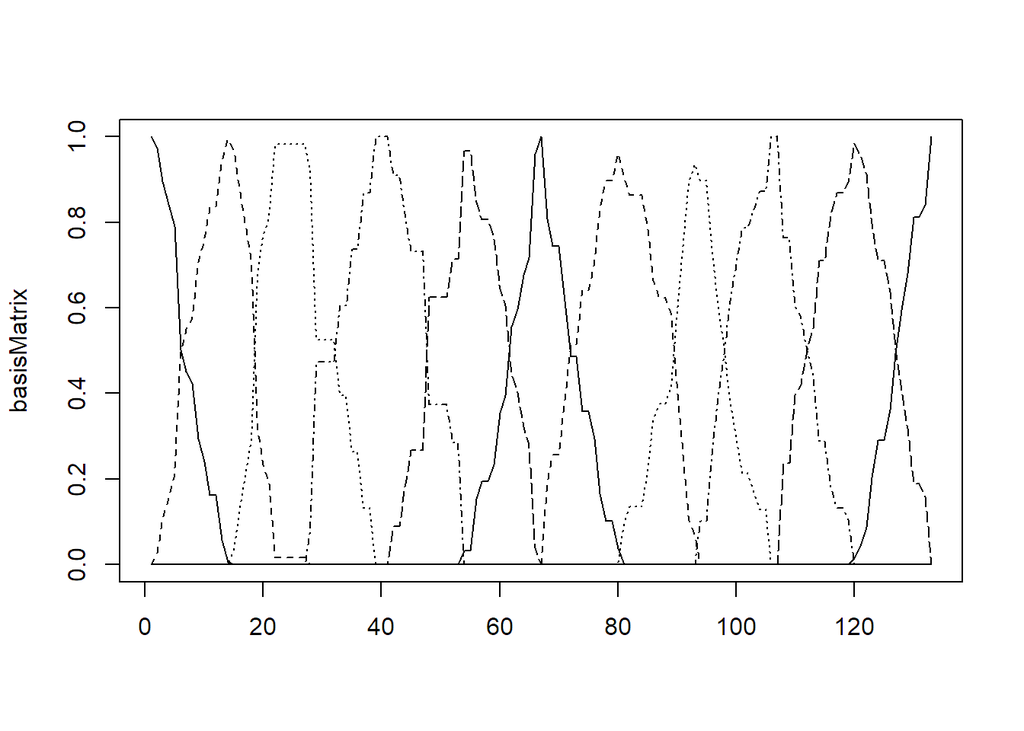

```r
  # the bases look like this WRT the x-variable "times" - bit ugly due to small dataset
  matplot(basisMatrix, type='l', col='black')
```

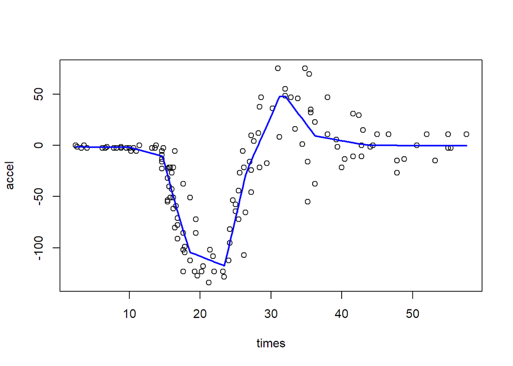

```r
  # given the basis matrix, use OLS as the loss function - f is a linear combination of bases
  fittedCubic<- lm(accel~basisMatrix-1, data=mcycle)

  # which gives this result fitted to the data
  plot(mcycle)

  lines(mcycle$times, fitted(fittedCubic), col='blue', lwd=2)
```

Do as before, but now use cubic bases - this will make for a smoother result.

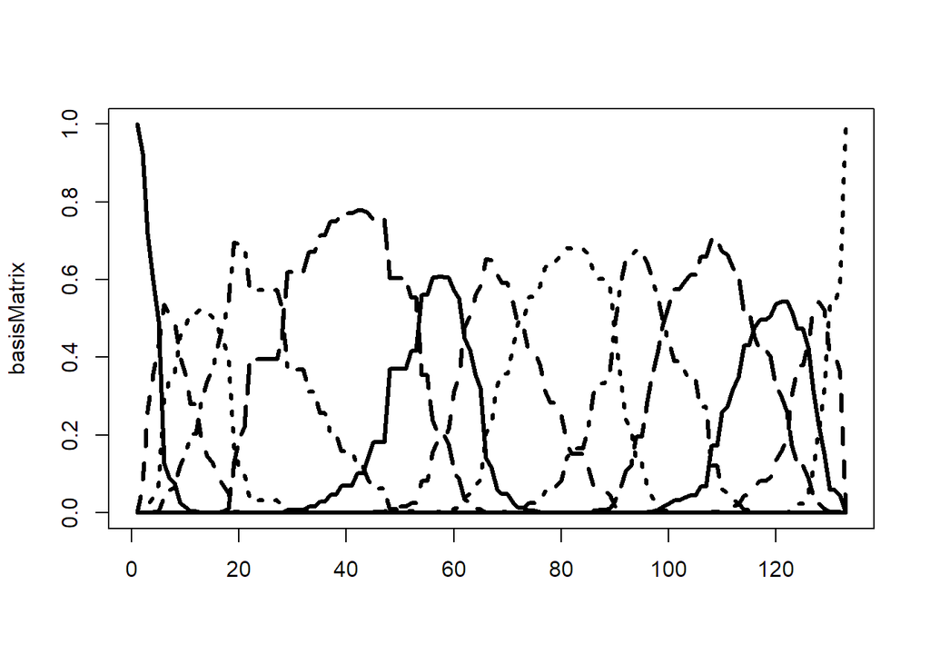

```r
  basisMatrix<- bs(mcycle$times, knots=knots[-11])

  matplot(basisMatrix, type='l', col='black', lwd=3)
```

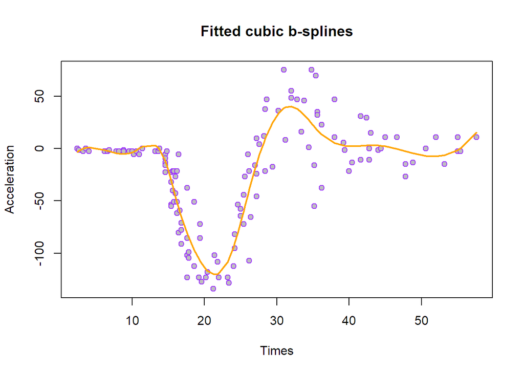

```r
  fittedCubic<- lm(accel~basisMatrix-1, data=mcycle)

  # plot - a little prettier
  plot(mcycle$times, mcycle$accel, col='purple1', pch=21, bg='grey',
       xlab='Times', ylab='Acceleration', main='Fitted cubic b-splines')

  lines(mcycle$times, fitted(fittedCubic), col='orange', lwd=2)
```

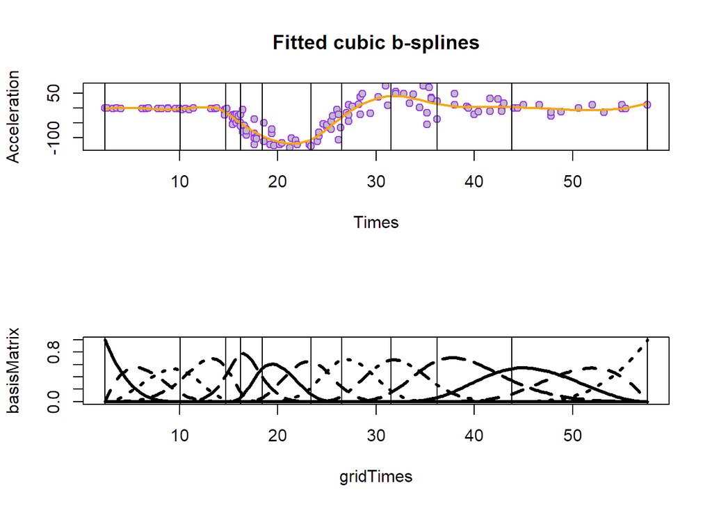

```r
  par(mfrow=c(2,1))

  # plot - a little prettier
  plot(mcycle$times, mcycle$accel, col='purple1', pch=21, bg='grey',
       xlab='Times', ylab='Acceleration', main='Fitted cubic b-splines')

  lines(mcycle$times, fitted(fittedCubic), col='orange', lwd=2)

  abline(v=knots)

  # evaluate the bases on a finer scale

  gridTimes<- seq(min(mcycle$times), max(mcycle$times), length=200)

  basisMatrix<- bs(gridTimes, knots=knots[-11])

  matplot(gridTimes, basisMatrix, type='l', col='black', lwd=3)

  abline(v=knots)
```

## Higher dimesional bases

If we’re dealing with more covariates/features, then the bases may be in more dimensions. We’ll see this in later models e.g. tree methods and NNs. The dimension is often large, although within the dimension of the covariate/feature space.

Start with the simplest thing around - piecewise constants.

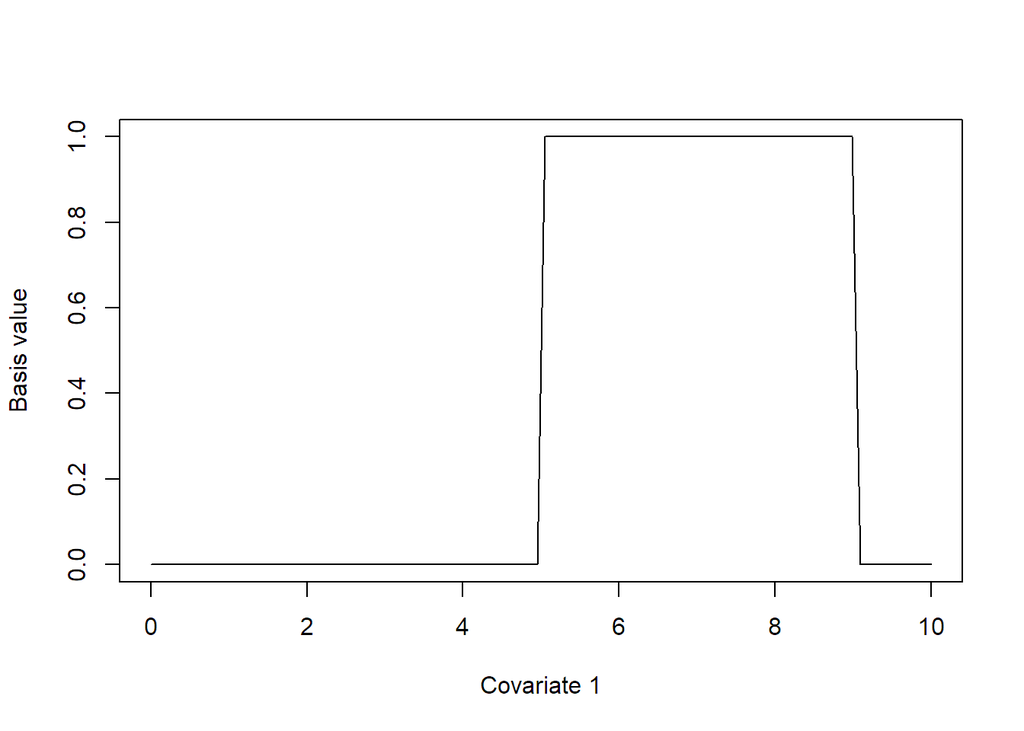

```r
  #= Produce some contrived data

    Covariate1<- seq(0, 10, length=100)
    Covariate2<- seq(20, 40, length=100)


  #= Define a simple marginal basis function as 1 if 5<=x1<9, zero elsewhere
    BlockBasisX1<- ifelse(Covariate1>=5&Covariate1<9, 1, 0)
    plot(Covariate1, BlockBasisX1, type='l', ylab='Basis value', xlab='Covariate 1')
```

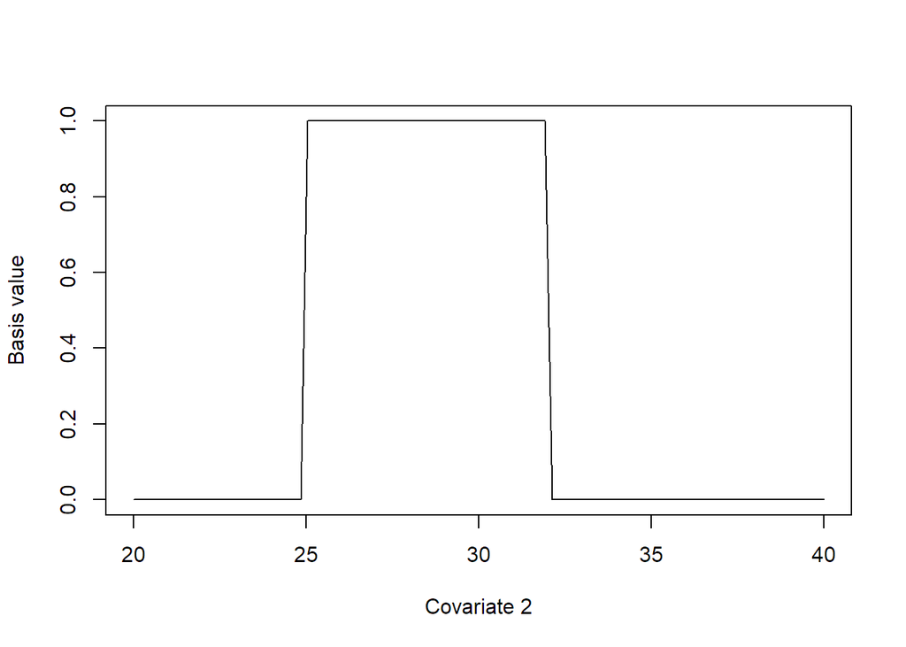

```r
  #= Define a simple marginal basis function as 1 if 25<=x2<32, zero elsewhere
    BlockBasisX2<- ifelse(Covariate2>=25&Covariate2<32, 1, 0)
    plot(Covariate2, BlockBasisX2, type='l', ylab='Basis value', xlab='Covariate 2')
```

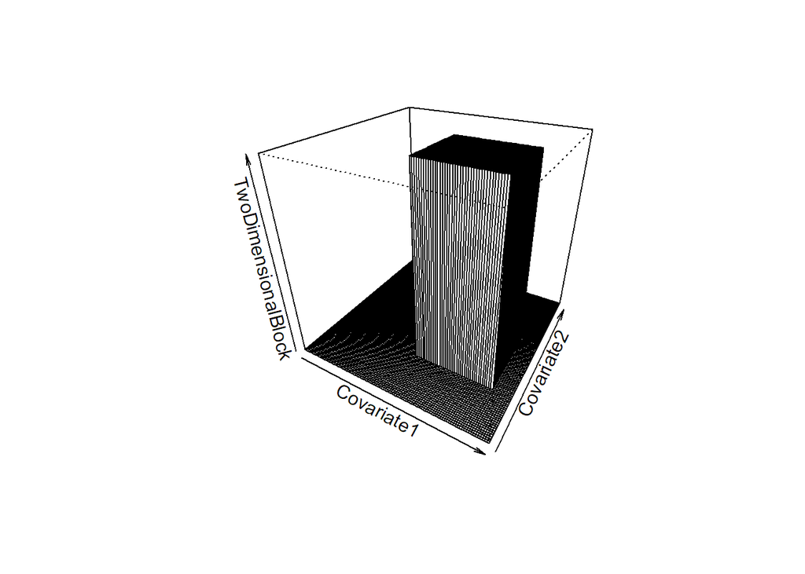

```r
  #= Develop a simple 2D variant from these

    TwoDimensionalBlock<- BlockBasisX1%*%t(BlockBasisX2)
    persp(Covariate1, Covariate2, TwoDimensionalBlock, theta=30, phi=30)
```

As before, we change the nature of the curves by using a different basis type. Here we build with smooth bases to move towards a smooth $f$.

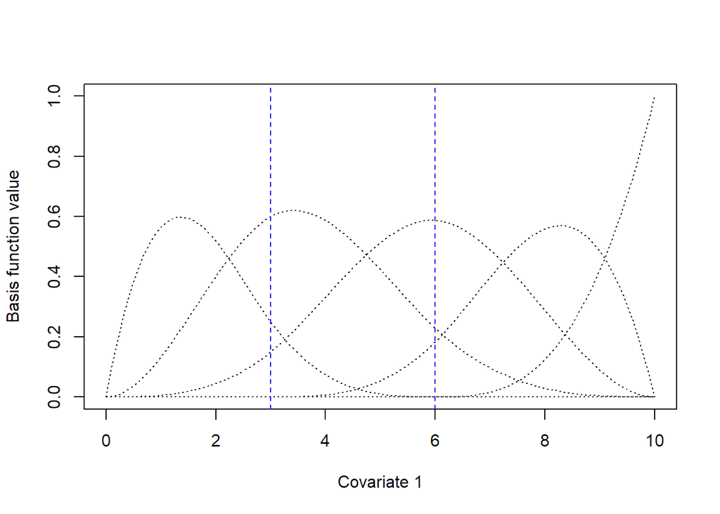

```r
  #= Repeat this process for a cubic b-spline basis

  #= Create b-spline sets for both covariates


    BSMatrixX1<- bs(Covariate1, knots=c(3,6))
    BSMatrixX2<- bs(Covariate2, knots=c(25, 30, 35))

    matplot(Covariate1, BSMatrixX1, type='l', lty=3, xlab='Covariate 1', ylab='Basis function value', col=1)
    abline(v=c(3,6), lty=2, col='blue') # knot locations
```

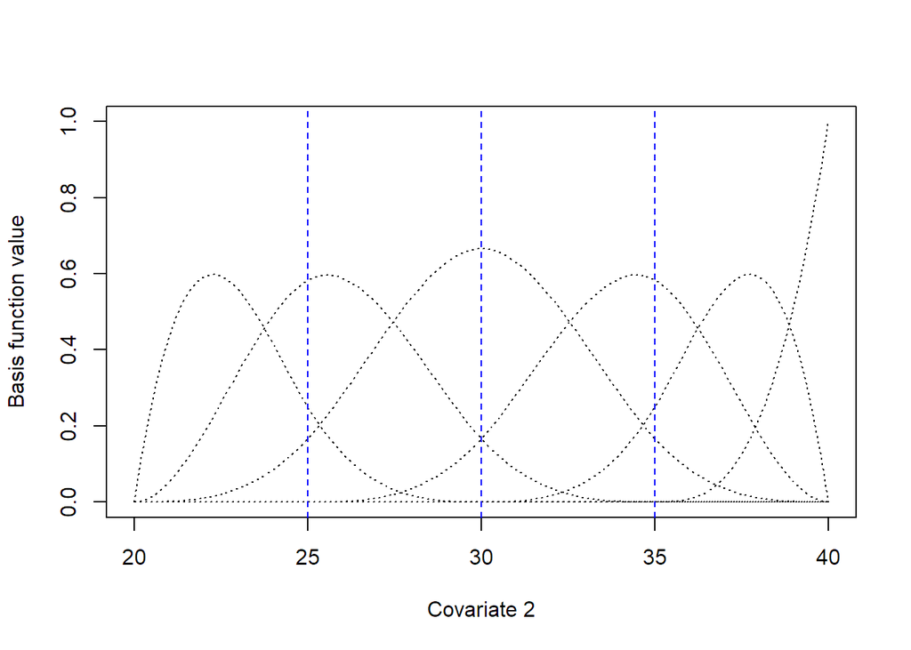

```r
    matplot(Covariate2, BSMatrixX2, type='l', lty=3, xlab='Covariate 2', ylab='Basis function value', col=1)
    abline(v=c(25, 30, 35), lty=2, col='blue') # knot locations
```

Multiplying these into 2-D space still retains their inherent smoothness.

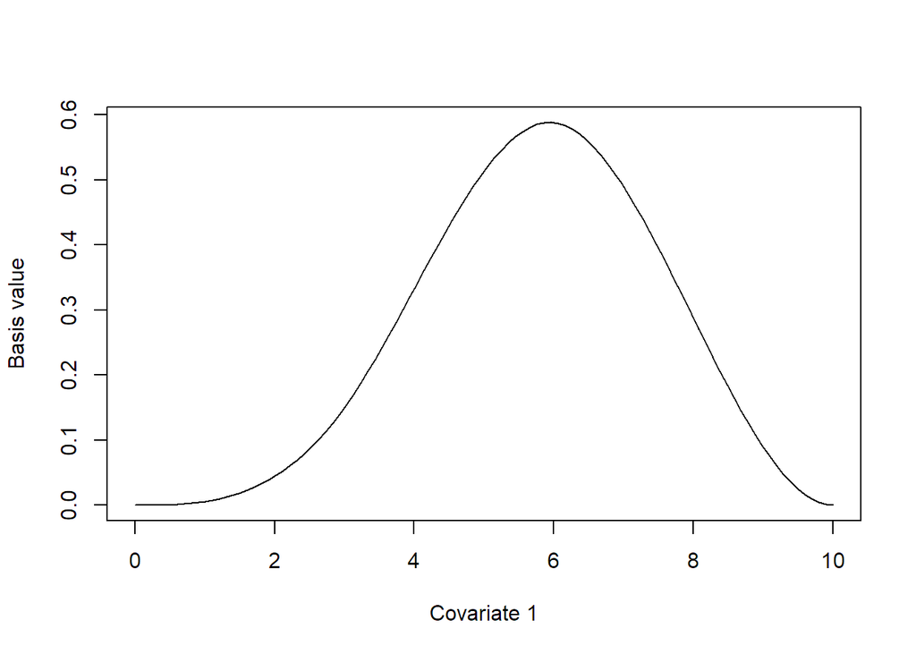

```r
  #= Create a tensor version from a couple of these

    BSplineTensor<- BSMatrixX1[,3]%*%t(BSMatrixX2[,5])

    #= plot the marginal bases we will combine
    plot(Covariate1, BSMatrixX1[,3], xlab='Covariate 1', ylab='Basis value', type='l')
```

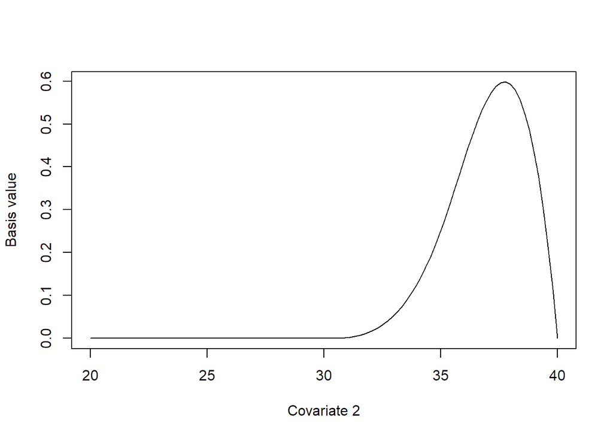

```r
    plot(Covariate2, BSMatrixX2[,5], xlab='Covariate 2', ylab='Basis value', type='l')
```

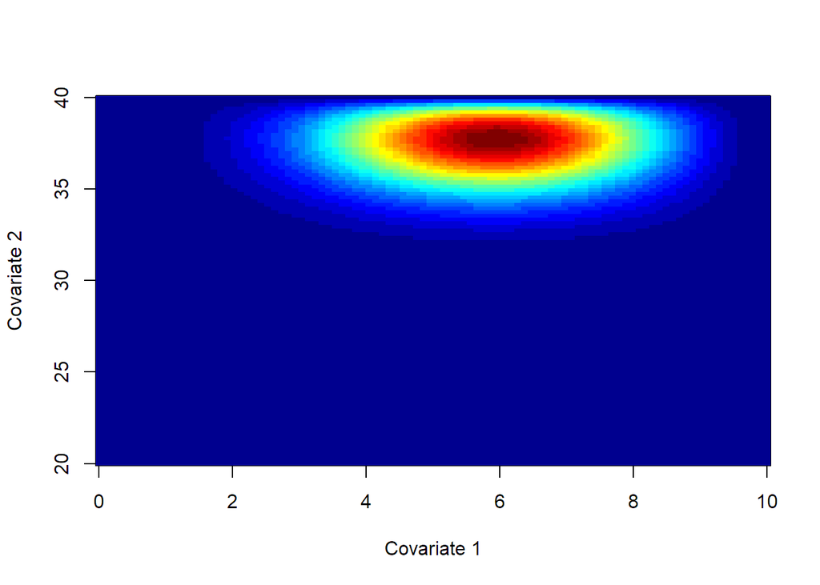

```r
    #= pretty-ish pictures of the combination
    image(Covariate1, Covariate2, BSplineTensor, xlab='Covariate 1', ylab='Covariate 2', col=tim.colors(n=30))
```

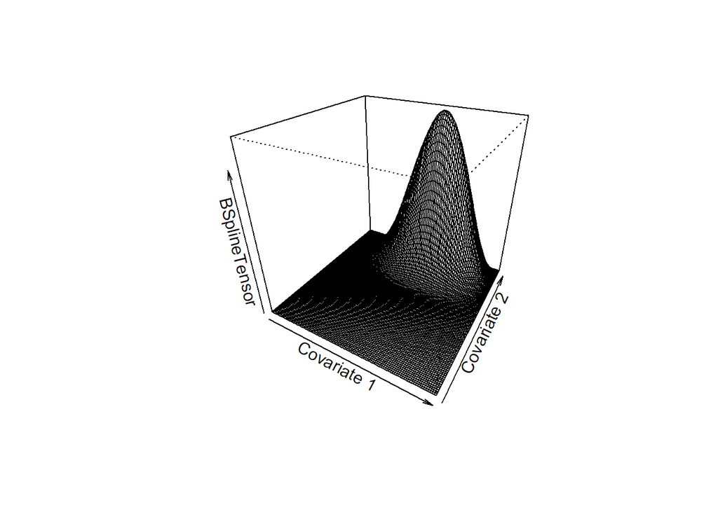

```r
    persp(Covariate1, Covariate2, BSplineTensor, xlab='Covariate 1', ylab='Covariate 2', theta=30, phi=30)
```

The following will give a little interactive 3-D version using the library `RGL`. It will open in its own window.

```r
#============================================================================================#
  #= Do pretty much the same thing, but in RGL for a laugh

  open3d()
```

```
## wgl
##   1
```

```r
  #= setups
  bg3d(color="#887777")
  light3d()

  #= put the surface in for the bivariate basis function - scale z a bit as it is relatively small

  surface3d(Covariate1,Covariate2, 20*BSplineTensor,color="purple",alpha=0.5, front="lines")

  #= add the univariate bases that generated the bivariate one

  rgl.lines(Covariate1, rep(45, length(Covariate1)), 10*BSMatrixX1[,3],col="#000000", lwd=2)
  rgl.lines(rep(1, length(Covariate2)), Covariate2, 10*BSMatrixX2[,5],col="#000000", lwd=2)

  #= stick a wee box around all this. Note z scale is not what is actually in the data for disply purposes
  bbox3d(col='white', alpha=0.5)
```